Exercise 5 Claire Brandes 2024-03-07

# Challenge 1

## Step 1

Using the {tidyverse} read_csv() function, load the “IMDB-movies.csv” data set as a “tibble” named **d**.

```r
library(readr)
f <- "https://raw.githubusercontent.com/difiore/ada-2024-datasets/main/IMDB-movies.csv"
d <- read_csv(f, col_names = TRUE)
```

## Step 2

Use a one-line statement to filter the data set to include just movies from 1920 to 1979 and moves that are between 1 and 3 hours long (**runtimeMinutes** >= 60 and **runtimeMinutes** <= 180), and add a new column that codes the startYear into a new variable, **decade** (“20s”, “30s”,…“70s”). There are now 5651 movies remaining in the data set.

```r
library(dplyr)
d <- d %>%
  filter(between(startYear, 1920, 1979)) %>%
  filter(between(runtimeMinutes, 60, 180)) %>%
  mutate(decade = case_when(
    startYear <= 1929 ~ "20s",
    startYear <= 1939 ~ "30s",
    startYear <= 1949 ~ "40s",
    startYear <= 1959 ~ "50s",
    startYear <= 1969 ~ "60s",
    startYear <= 1979 ~ "70s",
    TRUE ~ NA
  ))
```

## Step 3

Use {ggplot2} to plot histograms of the distribution of **runtimeMinutes** for each decade.

```r
library(tidyverse)
```

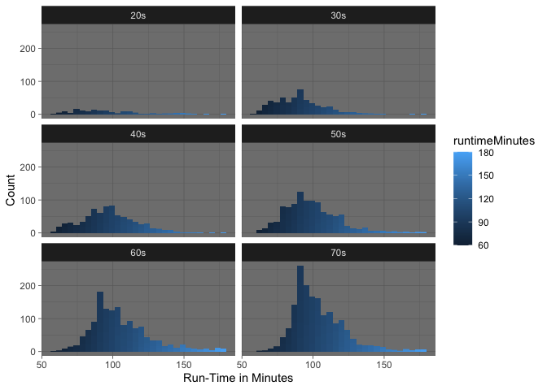

```r
ggplot(data = d, mapping = aes(x = runtimeMinutes, group = runtimeMinutes, fill = runtimeMinutes)) +
  ylab("Count") + xlab("Run-Time in Minutes") +
  geom_histogram(bins = 30) +
  facet_wrap(vars(decade), nrow = 5, ncol = 2) +
  theme_dark()
```

## Step 4

Use a one-line statement to calculate the population mean and population standard deviation in runtimeMinutes for each decade and save the results in a new data frame called **results**.

```r
(results <- d %>% group_by(decade) %>%
  summarise(
    pop_mean = mean(runtimeMinutes),
    pop_sd = sd(runtimeMinutes)
  ))
```

```
## # A tibble: 6 × 3
##   decade pop_mean pop_sd
##   <chr>     <dbl>  <dbl>
## 1 20s        96.3   26.2
## 2 30s        90.3   17.3
## 3 40s        97.2   19.1
## 4 50s        98.9   19.2
## 5 60s       106.    21.2
## 6 70s       104.    18.0
```

## Step 5

Draw a single sample of 100 movies, without replacement, from each decade and calculate the single sample mean and single sample standard deviation in **runtimeMinutes** for each decade.

```r
s <- d %>% group_by(decade) %>%
  sample_n(size = 100, replace = FALSE)
```

Calculating single sample mean and single standard deviation in runtimeMinutes for each decade:

```r
(sample_results <- s %>% group_by(decade) %>%
  summarise(
    sample_mean = mean(runtimeMinutes),
    sample_sd = sd(runtimeMinutes)
  ))
```

```
## # A tibble: 6 × 3
##   decade sample_mean sample_sd
##   <chr>        <dbl>     <dbl>
## 1 20s           97.5      26.3
## 2 30s           89.1      16.9
## 3 40s           97.1      18.8
## 4 50s           96.8      19.8
## 5 60s          106.       23.7
## 6 70s          102.       17.0
```

## Step 6

Calculate for each decade the standard error around your estimate of the population mean **runtimeMinutes** based on the standard deviation and sample size (n = 100 movies) of your single sample. Adding this data to the tibble created in Step 5:

```r
(sample_results <- s %>% group_by(decade) %>%
  summarise(
    sample_mean = mean(runtimeMinutes),
    sample_sd = sd(runtimeMinutes),
    std_error = sample_sd/sqrt(100)
  ))
```

```
## # A tibble: 6 × 4
##   decade sample_mean sample_sd std_error
##   <chr>        <dbl>     <dbl>     <dbl>
## 1 20s           97.5      26.3      2.63
## 2 30s           89.1      16.9      1.69
## 3 40s           97.1      18.8      1.88
## 4 50s           96.8      19.8      1.98
## 5 60s          106.       23.7      2.37
## 6 70s          102.       17.0      1.70
```

## Step 7

Compare these estimates to the actual population mean **runtimeMinutes** for each decade and to the calculated SE in the population mean for samples of size 100 based on the population standard deviation for each decade.

```r
full_join(results, sample_results)
```

```
## # A tibble: 6 × 6
##   decade pop_mean pop_sd sample_mean sample_sd std_error
##   <chr>     <dbl>  <dbl>       <dbl>     <dbl>     <dbl>
## 1 20s        96.3   26.2        97.5      26.3      2.63
## 2 30s        90.3   17.3        89.1      16.9      1.69
## 3 40s        97.2   19.1        97.1      18.8      1.88
## 4 50s        98.9   19.2        96.8      19.8      1.98
## 5 60s       106.    21.2       106.       23.7      2.37
## 6 70s       104.    18.0       102.       17.0      1.70
```

## Step 8

Generate a *sampling distribution* of mean **runtimeMinutes** for each decade by [a] drawing 1000 random samples of 100 movies from each decade, without replacement, and, for each sample, [b] calculating the mean **runtimeMinutes** and the standard deviation in **runtimeMinutes** for each decade.

```r
library(mosaic)
reps <- 1000

(samp_dist <- do(reps) * sample_n(group_by(d, decade), 100, replace = FALSE) %>%
  summarise(
    samp_dist_mean = mean(runtimeMinutes),
    samp_dist_sd = sd(runtimeMinutes)
  ))
```

```
## # A tibble: 6,000 × 5
##    decade samp_dist_mean samp_dist_sd  .row .index
##    <chr>           <dbl>        <dbl> <int>  <dbl>
##  1 20s              96.3         26.3     1      1
##  2 30s              90.4         17.5     2      1
##  3 40s              95.2         20.3     3      1
##  4 50s              96.8         18.9     4      1
##  5 60s             110.          22.1     5      1
##  6 70s             102.          16.4     6      1
##  7 20s              97.1         27.0     1      2
##  8 30s              90.2         18.0     2      2
##  9 40s              95.4         19.2     3      2
## 10 50s              95.9         17.5     4      2
## # ℹ 5,990 more rows
```

## Step 9

Calculate the **mean** and the **standard deviation** of the sampling distribution of sample means for each decade and plot a histogram of the sampling distribution for each decade.

```r
mean(samp_dist$samp_dist_mean)
```

```
## [1] 98.65472
```

```r
sd(samp_dist$samp_dist_sd)
```

```
## [1] 3.39185
```

Plotting histogram of the sampling distribution for each decade:

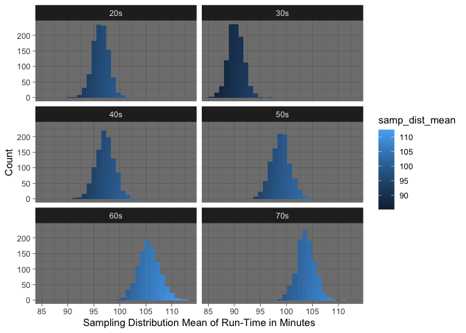

```r
ggplot(data = samp_dist, mapping = aes(x = samp_dist_mean, group = samp_dist_mean, fill = samp_dist_mean)) +
  ylab("Count") + xlab("Sampling Distribution Mean of Run-Time in Minutes") +
  geom_histogram(bins = 30) +
  facet_wrap(vars(decade), nrow = 5, ncol = 2) +
  theme_dark()
```

Each histogram is shaped like a normal curve.

## Step 10

Compare the standard error in **runtimeMinutes** for samples of size 100 for each decade [1] as estimated from the **first** sample of 100 movies, [2] as calculated from the known *population* standard deviations for each decade, and [3] as estimated from the sampling distribution of sample means for each decade.

Estimating standard error from the first sample of 100 movies (copied from step 6), and pulling out the standard error data:

```r
(single_sample_SE <- (sample_results <- s %>% group_by(decade) %>%
  summarise(
    sample_sd = sd(runtimeMinutes),
    sample_std_error = sample_sd/sqrt(100)
  )))
```

```
## # A tibble: 6 × 3
##   decade sample_sd sample_std_error
##   <chr>      <dbl>            <dbl>
## 1 20s         26.3             2.63
## 2 30s         16.9             1.69
## 3 40s         18.8             1.88
## 4 50s         19.8             1.98
## 5 60s         23.7             2.37
## 6 70s         17.0             1.70
```

```r
(single_sample_SE <- single_sample_SE %>% select(decade, sample_std_error))
```

```
## # A tibble: 6 × 2
##   decade sample_std_error
##   <chr>             <dbl>
## 1 20s                2.63
## 2 30s                1.69
## 3 40s                1.88
## 4 50s                1.98
## 5 60s                2.37
## 6 70s                1.70
```

Standard error from the known population standard deviations (mostly copied from step 4, just added SE calculation) and pulling out standard error data:

```r
(results <- d %>% group_by(decade) %>%
  summarise(
    pop_sd = sd(runtimeMinutes),
    pop_std_error = pop_sd/sqrt(100)
  ))
```

```
## # A tibble: 6 × 3
##   decade pop_sd pop_std_error
##   <chr>   <dbl>         <dbl>
## 1 20s      26.2          2.62
## 2 30s      17.3          1.73
## 3 40s      19.1          1.91
## 4 50s      19.2          1.92
## 5 60s      21.2          2.12
## 6 70s      18.0          1.80
```

```r
(results <- results %>% select(decade, pop_std_error))
```

```
## # A tibble: 6 × 2
##   decade pop_std_error
##   <chr>          <dbl>
## 1 20s             2.62
## 2 30s             1.73
## 3 40s             1.91
## 4 50s             1.92
## 5 60s             2.12
## 6 70s             1.80
```

```r
(samp_dist_SE <- samp_dist %>% group_by(decade) %>%
  summarise(
    samp_dist_std_error = samp_dist_sd
  ))
```

```
## # A tibble: 6,000 × 2
## # Groups:   decade [6]
##    decade samp_dist_std_error
##    <chr>                <dbl>
##  1 20s                   26.3
##  2 20s                   27.0
##  3 20s                   26.1
##  4 20s                   25.8
##  5 20s                   25.6
##  6 20s                   25.6
##  7 20s                   27.9
##  8 20s                   27.8
##  9 20s                   25.9
## 10 20s                   27.2
## # ℹ 5,990 more rows
```

```r
(samp_dist_SE <- samp_dist_SE %>% select(samp_dist_std_error))
```

```
## # A tibble: 6,000 × 2
## # Groups:   decade [6]
##    decade samp_dist_std_error
##    <chr>                <dbl>
##  1 20s                   26.3
##  2 20s                   27.0
##  3 20s                   26.1
##  4 20s                   25.8
##  5 20s                   25.6
##  6 20s                   25.6
##  7 20s                   27.9
##  8 20s                   27.8
##  9 20s                   25.9
## 10 20s                   27.2
## # ℹ 5,990 more rows
```

Comparing the standard errors from all three methods of calculation:

```r
(step10 <- full_join(results, single_sample_SE))
```

```
## # A tibble: 6 × 3
##   decade pop_std_error sample_std_error
##   <chr>          <dbl>            <dbl>
## 1 20s             2.62             2.63
## 2 30s             1.73             1.69
## 3 40s             1.91             1.88
## 4 50s             1.92             1.98
## 5 60s             2.12             2.37
## 6 70s             1.80             1.70
```

```r
(step10 <- full_join(step10, samp_dist_SE)) # tried to find a better way to join multiple data tables but couldn't :(
```

```
## # A tibble: 6,000 × 4
##    decade pop_std_error sample_std_error samp_dist_std_error
##    <chr>          <dbl>            <dbl>               <dbl>
##  1 20s             2.62             2.63                26.3
##  2 20s             2.62             2.63                27.0
##  3 20s             2.62             2.63                26.1
##  4 20s             2.62             2.63                25.8
##  5 20s             2.62             2.63                25.6
##  6 20s             2.62             2.63                25.6
##  7 20s             2.62             2.63                27.9
##  8 20s             2.62             2.63                27.8
##  9 20s             2.62             2.63                25.9
## 10 20s             2.62             2.63                27.2
## # ℹ 5,990 more rows
```

# Challenge 2

## Step 1

Loading “zombies.csv” data set as a tibble names **z**.

```r
f2 <- "https://raw.githubusercontent.com/difiore/ada-2024-datasets/main/zombies.csv"
z <- read_csv(f2, col_names = TRUE)
```

## Step 2

Calculate the *population* mean and standard deviation for each quantitative random variable in the data set (height, weight, age, number of zombies killed, and years of education)

```r
library(radiant)
(z_step2 <- z %>%
  summarise(
    height_mean = mean(height),
    weight_mean = mean(weight),
    age_mean = mean(age),
    zombies_killed_mean = mean(zombies_killed),
    education_mean = mean(years_of_education),

    height_sd = sdpop(height),
    weight_sd = sdpop(weight),
    age_sd = sdpop(age),
    zombies_killed_sd = sdpop(zombies_killed),
    education_sd = sdpop(years_of_education)
  ))
```

```
## # A tibble: 1 × 10
##   height_mean weight_mean age_mean zombies_killed_mean education_mean height_sd
##         <dbl>       <dbl>    <dbl>               <dbl>          <dbl>     <dbl>
## 1        67.6        144.     20.0                2.99           3.00      4.31
## # ℹ 4 more variables: weight_sd <dbl>, age_sd <dbl>, zombies_killed_sd <dbl>,
## #   education_sd <dbl>
```

## Step 3

**Use {ggplot} and make boxplots of each of these variables by gender**

Boxplot of height by gender:

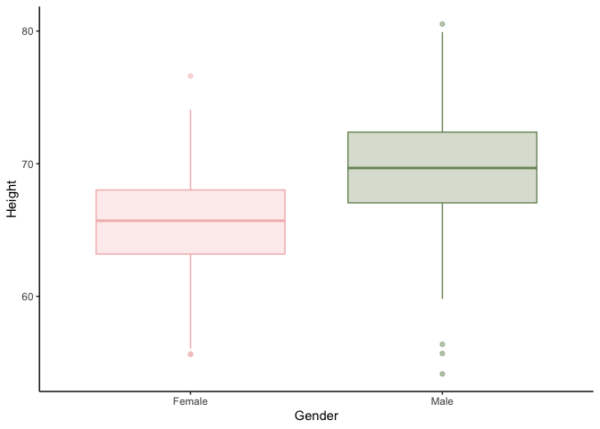

```r
ggplot(data = z, aes(x = gender, y = height, fill = gender, color = gender, alpha = gender)) +
  geom_boxplot(show.legend = FALSE) +
  xlab("Gender") + ylab("Height") +
  theme_classic() +
  scale_fill_manual(values = c("#FBDDDD", "#BAC2AB")) +
  scale_color_manual(values = c("#F3BABA", "#799567")) +
  scale_alpha_manual(values = c(0.5, 0.5))
```

Boxplot of weight by gender:

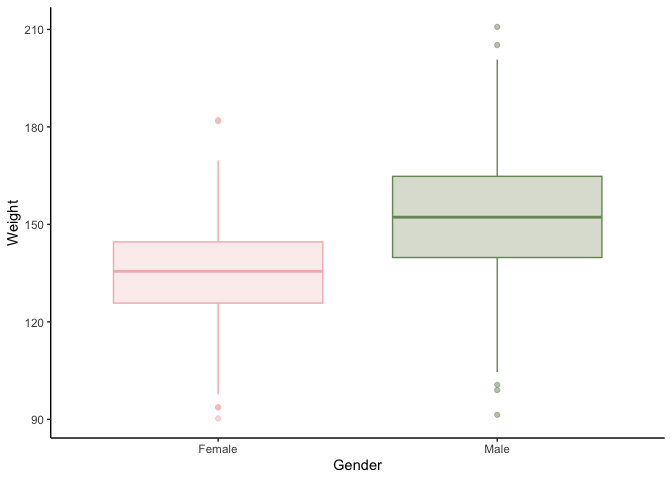

```r
ggplot(data = z, aes(x = gender, y = weight, fill = gender, color = gender, alpha = gender)) +
  geom_boxplot(show.legend = FALSE) +
  xlab("Gender") + ylab("Weight") +
  theme_classic() +
  scale_fill_manual(values = c("#FBDDDD", "#BAC2AB")) +
  scale_color_manual(values = c("#F3BABA", "#799567")) +
  scale_alpha_manual(values = c(0.5, 0.5))
```

Boxplot of age by gender:

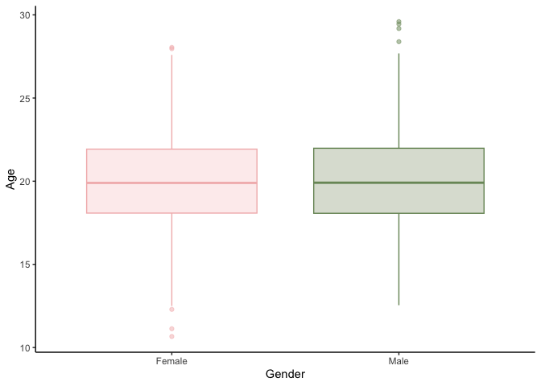

```r
ggplot(data = z, aes(x = gender, y = age, fill = gender, color = gender, alpha = gender)) +
  geom_boxplot(show.legend = FALSE) +
  xlab("Gender") + ylab("Age") +
  theme_classic() +
  scale_fill_manual(values = c("#FBDDDD", "#BAC2AB")) +
  scale_color_manual(values = c("#F3BABA", "#799567")) +
  scale_alpha_manual(values = c(0.5, 0.5))
```

Boxplot of number of zombies killed by gender:

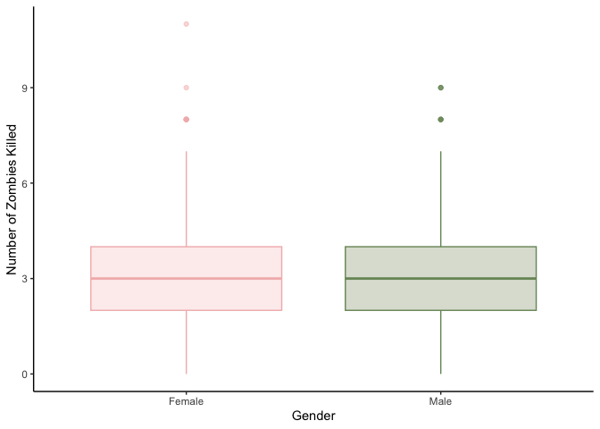

```r
ggplot(data = z, aes(x = gender, y = zombies_killed, fill = gender, color = gender, alpha = gender)) +
  geom_boxplot(show.legend = FALSE) +
  xlab("Gender") + ylab("Number of Zombies Killed") +
  theme_classic() +
  scale_fill_manual(values = c("#FBDDDD", "#BAC2AB")) +
  scale_color_manual(values = c("#F3BABA", "#799567")) +
  scale_alpha_manual(values = c(0.5, 0.5))
```

Boxplot of number of years of education by gender:

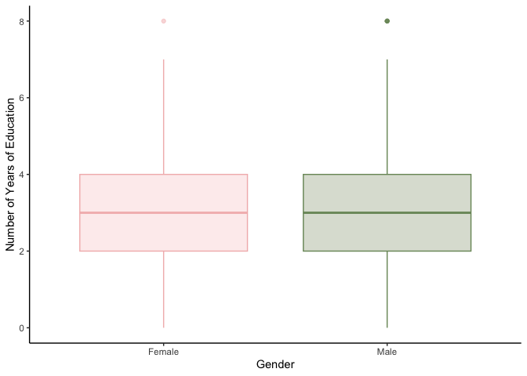

```r
ggplot(data = z, aes(x = gender, y = years_of_education, fill = gender, color = gender, alpha = gender)) +
  geom_boxplot(show.legend = FALSE) +
  xlab("Gender") + ylab("Number of Years of Education") +
  theme_classic() +
  scale_fill_manual(values = c("#FBDDDD", "#BAC2AB")) +
  scale_color_manual(values = c("#F3BABA", "#799567")) +
  scale_alpha_manual(values = c(0.5, 0.5))
```

## Step 4

Use {ggplot} and make scatterplots of height and weight in relation to age, using different colored points for males vs. females. Do these variables seem to be related? In what way?

First, creating plot of height in relation to age:

```r
age_height <- ggplot(data = z, aes(x = age, y= height, color = gender)) +
  geom_point() +
  geom_smooth(method = "lm") +
  theme_classic() +
  scale_color_manual(values = c("#FBDDDD", "#BAC2AB")) +
  xlab("Age") + ylab("Height") + labs(title = "Height as a Function of Age in Zombie Apocalypse Survivors") + labs(color = "Gender")
```

Second, creating plot of weight in relation to age:

```r
age_weight <- ggplot(data = z, aes(x = age, y= weight, color = gender)) +
  geom_point() +
  geom_smooth(method = "lm") +
  theme_classic() +
  scale_color_manual(values = c("#FBDDDD", "#BAC2AB")) +
  xlab("Age") + ylab("Weight") + labs(title = "Weight as a Function of Age in Zombie Apocalypse Survivors") + labs(color = "Gender")
```

Arranging both graphs in one image for easier comparison:

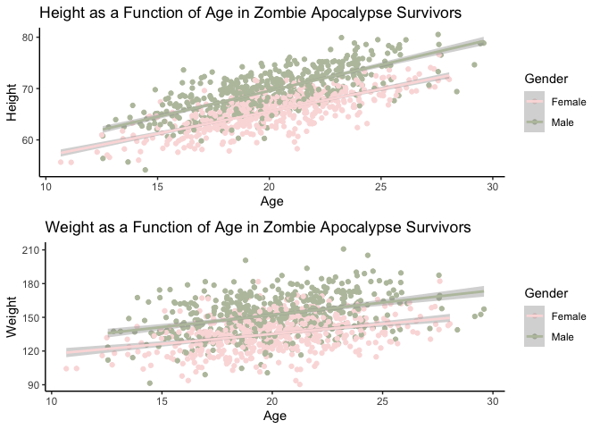

```r
library(ggpubr)
ggarrange(age_height, age_weight,
          ncol = 1, nrow = 2)
```

Height and weight both exhibit a positive correlation with age. Each sex exhibits its own linear regression equation for height and weight based on age since females tend to weigh less and are shorter than males.

## Step 5

Using histograms and Q_Q plots, check whether each of the quantitative variables seem to be drawn from a normal distribution. Which seem to be and which do not?

Creating a histogram of height:

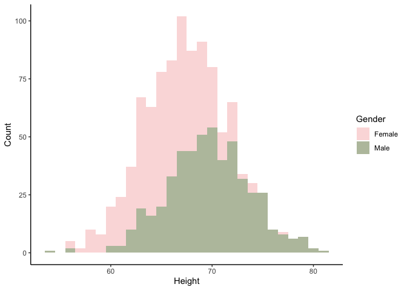

```r
ggplot(z, aes(x = height, group = gender, fill = gender)) +
  geom_histogram(binwidth = 1) +
  theme_classic() +
  scale_fill_manual(values = c("#FBDDDD", "#BAC2AB")) +
  xlab("Height") + ylab("Count") + labs(fill = "Gender")
```

In the population of zombie apocalypse survivors, height exhibits a fairly normal distribution overall, and each sex exhibits a normal distribution as well.

Creating a histogram of weight:

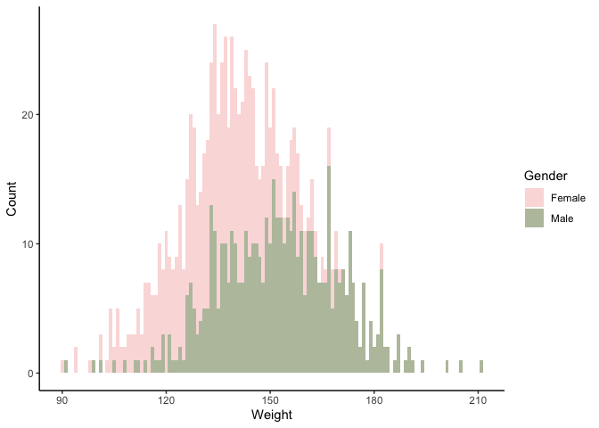

```r
ggplot(z, aes(x = weight, group = gender, fill = gender)) +
  geom_histogram(binwidth = 1) +
  theme_classic() +
  scale_fill_manual(values = c("#FBDDDD", "#BAC2AB")) +
  xlab("Weight") + ylab("Count") + labs(fill = "Gender")
```

Once again, in the population of zombie apocalypse survivors, weight exhibits a roughly normal distribution overall, and each sex exhibits a normal distribution as well.

Creating a histogram of age:

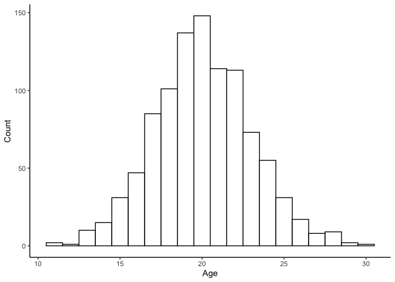

```r
ggplot(z, aes(x = age)) +
  geom_histogram(binwidth = 1, color = "black", fill = "white") +
  theme_classic() +
  xlab("Age") + ylab("Count")
```

Age also exhibits a normal distribution.

Histogram of number of zombies killed:

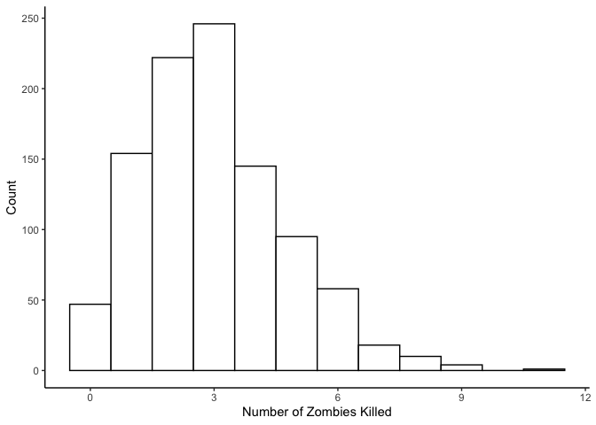

```r
ggplot(z, aes(x = zombies_killed)) +
  geom_histogram(binwidth = 1, color = "black", fill = "white") +
  theme_classic() +
  xlab("Number of Zombies Killed") + ylab("Count")
```

This distribution is not normal; it exhibits a heavy right skew. Most individuals have killed a low number of zombies.

Histogram of number of years of education:

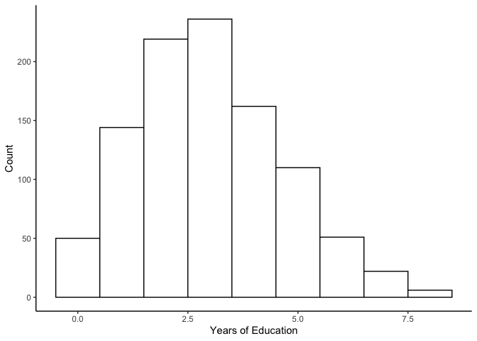

```r
ggplot(z, aes(x = years_of_education)) +
  geom_histogram(binwidth = 1, color = "black", fill = "white") +
  theme_classic() +
  xlab("Years of Education") + ylab("Count")
```

Now creating Q-Q plots.

Q-Q plot of height:

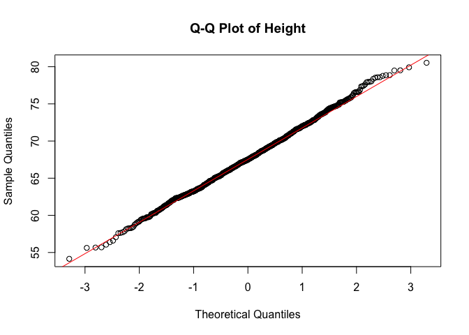

```r
qqnorm(z$height, main = "Q-Q Plot of Height")
qqline(z$height, col = "red")
```

Q-Q plot of weight:

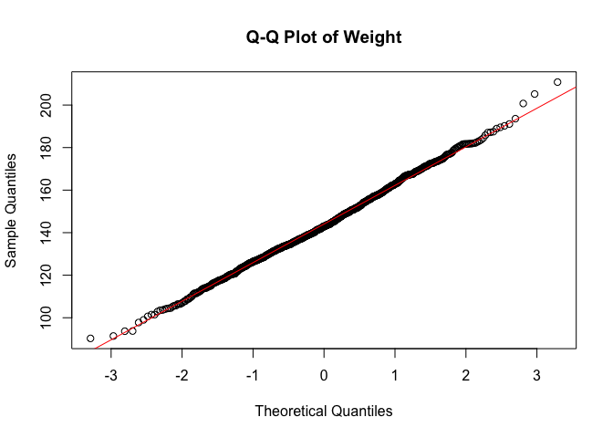

```r
qqnorm(z$weight, main = "Q-Q Plot of Weight")
qqline(z$weight, col = "red")
```

Q-Q plot of age:

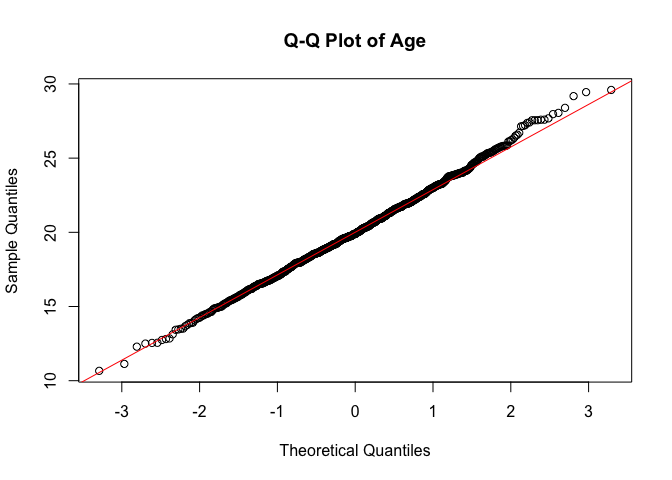

```r
qqnorm(z$age, main = "Q-Q Plot of Age")
qqline(z$age, col = "red")
```

Q-Q plot of number of zombies killed:

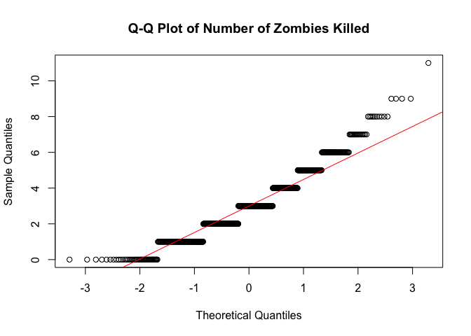

```r
qqnorm(z$zombies_killed, main = "Q-Q Plot of Number of Zombies Killed")
qqline(z$zombies_killed, col = "red")
```

Q-Q plot of years of education:

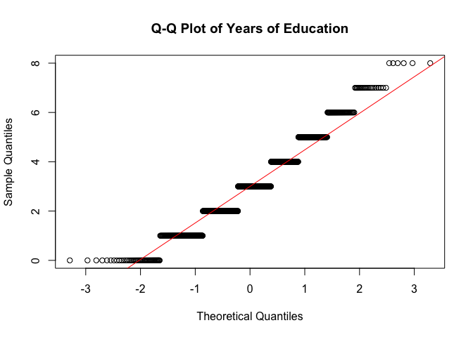

```r
qqnorm(z$years_of_education, main = "Q-Q Plot of Years of Education")
qqline(z$years_of_education, col = "red")
```

The Q-Q plots corroborate my answers above. Height, weight, and age exhibit normal distributions, while number of zombies killed and years of education do not.

## Step 6

Use the sample_n() or slice_sample() function from {dplyr} to sample ONE subset of 50 zombie apocalypse survivors (without replacement) from this population and calculate the mean and sample standard deviation for each variable.

Also estimate the standard error for each variable based on this one sample and use that to construct a theoretical 95% confidence interval for each mean. Use either the standard normal or a Student’s t distribution to derive the critical values needed to calculate the lower and upper limits of the CI.

Sampling subset of 50 survivors:

```r
z_sample <- z %>%
  sample_n(size = 50, replace = FALSE)
```

Calculating means for each variable:

```r
(z_sample_results <- z_sample %>%
  summarise(
    height_mean = mean(height),
    height_sd = sd(height),
    height_SE = height_sd/sqrt(50),

    weight_mean = mean(weight),
    weight_sd = sd(weight),
    weight_SE = weight_sd/sqrt(50),

    age_mean = mean(age),
    age_sd = sd(age),
    age_SE = age_sd/sqrt(50),

    zombies_killed_mean = mean(zombies_killed),
    zombies_killed_sd = sd(zombies_killed),
    zombies_killed_SE = zombies_killed_sd/sqrt(50),

    years_edu_mean = mean(years_of_education),
    years_edu_sd = sd(years_of_education),
    years_edu_SE = years_edu_sd/sqrt(50),
  ))
```

```
## # A tibble: 1 × 15
##   height_mean height_sd height_SE weight_mean weight_sd weight_SE age_mean
##         <dbl>     <dbl>     <dbl>       <dbl>     <dbl>     <dbl>    <dbl>
## 1        68.0      3.64     0.515        146.      16.1      2.27     20.6
## # ℹ 8 more variables: age_sd <dbl>, age_SE <dbl>, zombies_killed_mean <dbl>,
## #   zombies_killed_sd <dbl>, zombies_killed_SE <dbl>, years_edu_mean <dbl>,
## #   years_edu_sd <dbl>, years_edu_SE <dbl>
```

CI for height:

```r
alpha <- 0.05
lower_height <- z_sample_results$height_mean + qnorm(alpha/2) * z_sample_results$height_SE
upper_height <- z_sample_results$height_mean + z_sample_results$height_SE

(CI_height <- c(lower_height, upper_height))
```

```
## [1] 67.00046 68.52433
```

CI for weight:

```r
lower_weight <- z_sample_results$weight_mean + qnorm(alpha/2) * z_sample_results$weight_SE
upper_weight <- z_sample_results$weight_mean + z_sample_results$weight_SE

(CI_weight <- c(lower_weight, upper_weight))
```

```
## [1] 141.2002 147.9322
```

CI for age:

```r
lower_age <- z_sample_results$age_mean + qnorm(alpha/2) * z_sample_results$age_SE
upper_age <- z_sample_results$age_mean + z_sample_results$age_SE

(CI_age <- c(lower_age, upper_age))
```

```
## [1] 19.70653 21.04894
```

CI for number of zombies killed:

```r
lower_zombies <- z_sample_results$zombies_killed_mean + qnorm(alpha/2) * z_sample_results$zombies_killed_SE
upper_zombies <- z_sample_results$zombies_killed_mean + z_sample_results$zombies_killed_SE

(CI_zombies <- c(lower_zombies, upper_zombies))
```

```
## [1] 2.469867 3.089255
```

CI for years of education:

```r
lower_edu <- z_sample_results$years_edu_mean + qnorm(alpha/2) * z_sample_results$years_edu_SE
upper_edu <- z_sample_results$years_edu_mean + z_sample_results$years_edu_SE

(CI_edu <- c(lower_edu, upper_edu))
```

```
## [1] 2.333745 3.188911
```

Organizing confidence intervals in a data frame:

```r
data.frame(CI_height, CI_weight, CI_age, CI_zombies, CI_edu, row.names = c("Lower", "Upper"))
```

```
##       CI_height CI_weight   CI_age CI_zombies   CI_edu
## Lower  67.00046  141.2002 19.70653   2.469867 2.333745
## Upper  68.52433  147.9322 21.04894   3.089255 3.188911
```

## Step 7

Draw another 199 random samples of 50 zombie apocalypse survivors out of the population and calculate the mean for each of these samples. Together with the first sample of 50, this constitutes a sampling distribution for each variable. What are the means and standard deviations of the **sampling distribution** for each variable? How do the standard deviations of the sampling distribution for each variable compare to the standard errors estimated from your first sample size of 50?

Drawing another 199 samples of 50 survivors:

```r
reps_z <- 199

(samp_dist_z <- do(reps_z) * sample_n(z, size = 50, replace = FALSE))
```

```
## # A tibble: 9,950 × 12
##       id first_name last_name gender height weight zombies_killed
##    <dbl> <chr>      <chr>     <chr>   <dbl>  <dbl>          <dbl>
##  1   620 Sarah      Mills     Female   62.5   117.              3
##  2   448 Nicholas   Black     Male     67.2   147.              1
##  3    60 Douglas    Murray    Male     70.4   144.              3
##  4   907 Sandra     West      Female   71.6   182.              3
##  5   136 Steven     Robinson  Male     67.6   146.              1
##  6   283 Gerald     Kelley    Male     73.6   172.              1
##  7   557 Rose       Sanders   Female   65.4   132.              2
##  8   629 Eugene     King      Male     73.8   159.              3
##  9    54 Marie      Butler    Female   62.4   141.              1
## 10   921 Jose       Turner    Male     69.5   144.              3
## # ℹ 9,940 more rows
## # ℹ 5 more variables: years_of_education <dbl>, major <chr>, age <dbl>,
## #   .row <int>, .index <dbl>
```

```r
(samp_dist_z_resulsts <- do(reps_z) * samp_dist_z %>%
  summarise(
    height_mean = mean(height),
    weight_mean = mean(weight),
    age_mean = mean(age),
    zombies_killed_mean = mean(zombies_killed),
    years_edu_mean = mean(years_of_education),
  ))
```

```
## # A tibble: 199 × 7
##    height_mean weight_mean age_mean zombies_killed_mean years_edu_mean  .row
##          <dbl>       <dbl>    <dbl>               <dbl>          <dbl> <int>
##  1        67.6        144.     20.0                2.99           2.98     1
##  2        67.6        144.     20.0                2.99           2.98     1
##  3        67.6        144.     20.0                2.99           2.98     1
##  4        67.6        144.     20.0                2.99           2.98     1
##  5        67.6        144.     20.0                2.99           2.98     1
##  6        67.6        144.     20.0                2.99           2.98     1
##  7        67.6        144.     20.0                2.99           2.98     1
##  8        67.6        144.     20.0                2.99           2.98     1
##  9        67.6        144.     20.0                2.99           2.98     1
## 10        67.6        144.     20.0                2.99           2.98     1
## # ℹ 189 more rows
## # ℹ 1 more variable: .index <dbl>
```

Combining first sample of 50 means with the other 199 to make a sampling distribution:

```r
(sample_200 <- full_join(samp_dist_z, z_sample)) # not sure why there's only 9950 rows instead of 10000 since I used full_join? Could not figure this out :(
```

[output not shown]

```
## # A tibble: 9,950 × 12
##       id first_name last_name gender height weight zombies_killed
##    <dbl> <chr>      <chr>     <chr>   <dbl>  <dbl>          <dbl>
##  1   620 Sarah      Mills     Female   62.5   117.              3
##  2   448 Nicholas   Black     Male     67.2   147.              1
##  3    60 Douglas    Murray    Male     70.4   144.              3
##  4   907 Sandra     West      Female   71.6   182.              3
##  5   136 Steven     Robinson  Male     67.6   146.              1
##  6   283 Gerald     Kelley    Male     73.6   172.              1
##  7   557 Rose       Sanders   Female   65.4   132.              2
##  8   629 Eugene     King      Male     73.8   159.              3
##  9    54 Marie      Butler    Female   62.4   141.              1
## 10   921 Jose       Turner    Male     69.5   144.              3
## # ℹ 9,940 more rows
## # ℹ 5 more variables: years_of_education <dbl>, major <chr>, age <dbl>,
## #   .row <int>, .index <dbl>
```

Calculating means and standard deviations of the full **sampling distribution** for each variable:

```r
(sample_200_results <- sample_200 %>%
  summarise(
    height_mean = mean(height),
    height_sd = sd(height),

    weight_mean = mean(weight),
    weight_sd = sd(weight),

    age_mean = mean(age),
    age_sd = sd(age),

    zombies_killed_mean = mean(zombies_killed),
    zombies_killed_sd = sd(zombies_killed),

    years_edu_mean = mean(years_of_education),
    years_edu_sd = sd(years_of_education),
  ))
```

```
## # A tibble: 1 × 10
##   height_mean height_sd weight_mean weight_sd age_mean age_sd
##         <dbl>     <dbl>       <dbl>     <dbl>    <dbl>  <dbl>
## 1        67.6      4.28        144.      18.3     20.0   2.93
## # ℹ 4 more variables: zombies_killed_mean <dbl>, zombies_killed_sd <dbl>,
## #   years_edu_mean <dbl>, years_edu_sd <dbl>
```

Standard deviations increased compared to the single sample of 50.

## Step 10

Finally, use bootstrapping to generate a 95% confidence interval for each variable mean **by resampling 1000 samples, with replacement, from your original sample** (i.e., by setting the upper and lower CI bounds to 2.5% and 97.5%% of the way through the sampling distribution generated by bootstrapping)

For height:

```r
z_boot <- 1000

boot_height <- vector(length = z_boot)
z_height <- length(sample_200)

for (i in 1:z_boot) {
  boot_height[[i]] <- mean(sample(sample_200_results$height_mean, z_height, replace = TRUE))
}

lowerh <- quantile(boot_height, 0.025)
upperh <- quantile(boot_height, 0.975)
(ci_boot_height <- c(lowerh, upperh))
```

```
##     2.5%    97.5%
## 22.74792 44.25208
```

For weight:

```r
boot_weight <- vector(length = z_boot)
z_weight <- length(sample_200)

for (i in 1:z_boot) {
  boot_weight[[i]] <- mean(sample(sample_200_results$weight_mean, z_height, replace = TRUE))
}

lowerw <- quantile(boot_weight, 0.025)
upperw <- quantile(boot_weight, 0.975)
(ci_boot_weight <- c(lowerw, upperw))
```

```
##     2.5%    97.5%
## 49.33333 95.67292
```

For age:

```r
boot_age <- vector(length = z_boot)
z_age <- length(sample_200)

for (i in 1:z_boot) {
  boot_age[[i]] <- mean(sample(sample_200_results$age_mean, z_age, replace = TRUE))
}

lowera <- quantile(boot_age, 0.025)
uppera <- quantile(boot_age, 0.975)
(ci_boot_age <- c(lowera, uppera))
```

```
##      2.5%     97.5%
##  7.247917 13.250000
```

For number of zombies killed:

```r
boot_zombies <- vector(length = z_boot)
z_zombies <- length(sample_200)

for (i in 1:z_boot) {
  boot_zombies[[i]] <- mean(sample(sample_200_results$zombies_killed_mean, z_zombies, replace = TRUE))
}

lowerzom <- quantile(boot_zombies, 0.025)
upperzom <- quantile(boot_zombies, 0.975)
(ci_boot_zombies <- c(lowerzom, upperzom))
```

```
##  2.5% 97.5%
##  1.25  1.75
```

For years of education:

```r
boot_edu <- vector(length = z_boot)
z_edu <- length(sample_200)

for (i in 1:z_boot) {
  boot_edu[[i]] <- mean(sample(sample_200_results$years_edu_mean, z_edu, replace = TRUE))
}

lowered <- quantile(boot_edu, 0.025)
uppered <- quantile(boot_edu, 0.975)
(ci_boot_edu <- c(lowered, uppered))
```

```
##  2.5% 97.5%
##  1.25  1.75
```